# ¶ S5 Efectos de la climatología (frío y calor) en el Desempeño Académico ¶

### c. Teorema de bayes

Para el análisis del Teorema de Bayes se realizó el siguiente esquema:

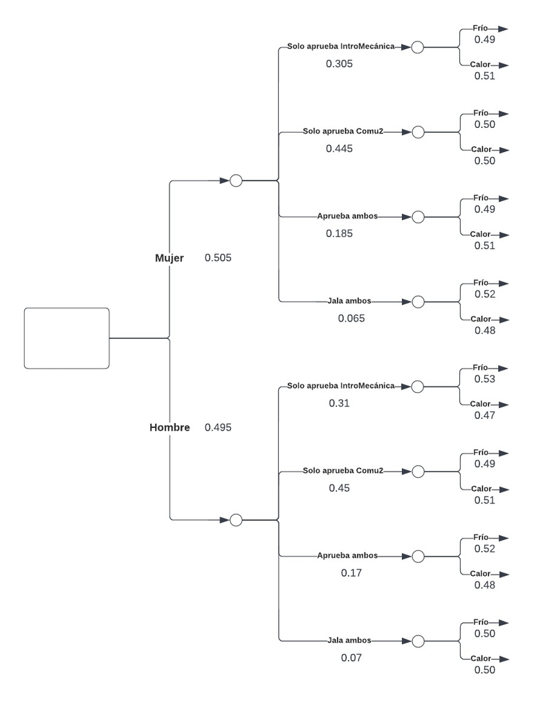

**Problema**:

En una evaluación cabe la posibilidad de aprobar 1 solo curso, 2 de ellos, ambos o jalar todos. En este caso se analiza los cursos de Intro a la Mecánica y Comu2, donde cada una de ellas se rindió en periodos diferentes: una en época de frío y el otro en época de calor. Además, sumarle a ello que el análisis se hará de forma independiente para cada género (hombre y mujer) Es por ello que para analizar los diversos casos se usa el teorema de Bayes.

Las preguntas a analizar son:

- ¿Cuál es la probabilidad de que ambos géneros aprueben ambos cursos en época de frío?

```r
round((0.505*0.185*0.49 + 0.495*0.17*0.52),4)
```

```
## [1] 0.0895
```

- ¿Cuál es la probabilidad de que ambos géneros aprueben ambos cursos en época de calor?

```r
round((0.505*0.185*0.51 + 0.495*0.17*0.48),4)
```

```
## [1] 0.088
```

Con ambos resultados verificamos que la probabilidad de aprobar ambos cursos en época de frío para ambos géneros es mayor a comparación de cuando hace calor con 0.0895 contra 0.088 respectivamente. Esto indica, que la época de frío es un buen momento para obtener mejores resultados, aunque la diferencia es mínima.

### ……………………………………………………………………………………………………

# **5. Modelos Probabilisticos**:

## 5.1 Distribuciones aleatorias discretas:

Para que una distribución sea discreta tiene que cumplirse que sus parámetros de éxito estén estandarizados, es decir, que cuando se replique nuestro experimento en otros contextos, los resultados muestren las mismas tendencias. Dado que es un experimento que antes no se ha realizado, no tenemos ningun dato estandarizado. No podemos suponer que nuestros casos de éxito serán las mismas si se replica nuestro estudio. Por ello, no podemos usar los modelos conocidos de distribuciones aleatorias discretas. Sin embargo, en lugar de ello podemos crear una función de distribución y hacer nuestro análisis de partir de ella.

### a. Función de Distribución:

**Problema:**

Se tienen diversas edades dentro de nuestro estudio, los cuáles conforman el 200 de nuestra muestra. Lo habitual es que alumnos del 3er ciclo tengan edades menor a los 21 años. Sin embargo, tambien se presentan casos donde estudiante sobrepasan esa límite. Por ello nos planteamos:

- ¿Cuál es la probabilidad de que las edades de los alumnos que se encuentran en el 3er ciclo de nuestro estudio tengan menos de 21 años?

$X$ Representa la edad de los alumnos de nuestra muestra del 3er ciclo

Para ello, usamos la siguiente tabla:

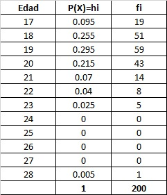

Entonces, sumando las probabilidades se tiene:

```r
round(0.095+0.255+0.295+0.215,2)
```

```
## [1] 0.86
```

Además se puede determinar cuántos tienen 21 o más años:

```r
1 - round(0.095+0.255+0.295+0.215,2)
```

```
## [1] 0.14
```

**Respuesta:**

La probabilidad de que la edad sea menor a 21 años es de 0.86, y que sea mayor o igual a 21 años es de 0.14. Eso quiere decir que la gran mayoría de las personas de nuestro estudio son jóvenes.

**Justificación:**

- Se creó este modelo dado que no podemos aplicar los modelos de distribución discretas conocidas. Esto porque no se tiene la certeza de que nuestros valores de éxito serán las mismas cuando se replique nuestro experimento bajo las mismas condiciones en otros contextos.

## 5.2. Distribuciones aleatorias continua:

### a. Distribución Normal:

**Problema:**

La variable nota se modela dentro de una distribución continua. El examen final de Comu2 se dio en un periodo donde hacia frio, por lo que con esta prueba se quiere saber la probabilidad de tener una nota aprobatoria cuando el clima sea frio. Por ello se plantea:

- ¿Cuál es la probabilidad de que la nota del examen final de Comu2 esté entre 11 a 20, sabiendo que la media es de 13.7 y la desviación estándar es 5.15?

$X$ Representa la nota del examen final de Comu2

Donde los parámetros son:

$P(11 < X < 20)$

**Respuesta:**

```r
round(pnorm(20, 13.7, 5.15) - pnorm(11, 13.7, 5.15),2)
```

```
## [1] 0.59
```

Por lo tanto, la probabilidad de aprobar el examen final de Comu2, lo que implica aprobar en época de frío, es de 0.59. Dicho valor muestra de que la tendencia a aprobar es más probable.

**Justificación:**

```r
cat('Moda:',round(Mode(Clima2$NFC),2),'\n')
```

```
## Moda: 15
```

```r
cat('Media:',round(mean(Clima2$NFC),2),'\n')
```

```
## Media: 13.7
```

```r
cat('Mediana:',round(median(Clima2$NFC),2),'\n')
```

```
## Mediana: 15
```

Sin embargo, nótese que la moda y mediana son las mismas (15), mientras que la media se acerca mucho a dicho valor (13.7). Dado que la proximidad es muy grande, tomamos que los 3 valores son semejantes entre si. Sin embargo, es recomendable que para que este análisis sea más pertinente los 3 valores sean idénticas.

### ……………………………………………………………………………………………………

# **6. Conclusiones**:

- Se evidencia que la tendencia a obtener mejores notas se da en el periodo de frio a comparación de calor. Ello se complementa con el estudio de referencia, pues indica que tomar evaluaciones en condiciones de altas temperaturas produce bochorno e incomodidad, por lo que los resultados en notas puede verse afectada. La misma conclusión fue la que obtuvimos en nuestro estudio.
- El calor afecta más el desempeño académico en varones que las mujeres. Sin embargo, en épocas de frío la tendencia cambia. Este comportamiento se correlaciona con las notas pues las mujeres tuvieron mejores resultados en los parciales (cuando hacía calor) y los hombres en los finales (cuando hacia frío).
- Es recomendable usar una muestra más grande para que la distribución, probabilidades, y análisis descriptivo abarque la totalidad de datos. Esto permite tener aproximaciones más exactas.
- La estadística permite hacer predicciones, por lo que se puede tomar nuestro estudio como punto de partida para poder generalizar resultados y verificar si realmente el clima afecta en el rendimiento de una evaluación en estudiantes. De esta forma, se pueden tomar medidas que permitan el confort de los estudiantes y tengan mejores resultados.